# Resetting `rtweet` authentication

Elgar Teo

March 18, 2021

This guide shows the steps of resetting the Twitter API authentication settings of the R package `rtweet`.

## Motivation

Recall when you are first introduced the package `rtweet`, you ran the following lines:

```r
appname <- "YOUR APP NAME"
consumerKey <- "YOUR CONSUMER KEY"
consumerSecret <- "YOUR CONSUMER SECRET"
access_token <- "YOUR ACCESS TOKEN"
access_secret <- "YOUR ACCESS SECRET"
twitter_token <- create_token(
  app = appname,
  consumer_key = consumerKey,
  consumer_secret = consumerSecret,
  access_token = access_token,
  access_secret = access_secret
)
```

The function `create_token()` creates a token, which contains the necessary authentication information for you to access Twitter API. This token is saved as a hidden file in your computer so that when you use `rtweet` next time you do not have to run the `create_token()` command again. It is like the ‘remember password’ feature in web browsers.

But if you have accidentally made a typo when entering the API key, or your key has become invalid, you will encounter authentication error when using `rtweet`:

```r
search_tweets("#AprilFools")
```

```
## data frame with 0 columns and 0 rows
```

This problem may persist even if you run the `create_token()` command again. It is because R has been configured to always use the old token. In this case, you need to remove the hidden token file with the old API key in your computer.

## How?

To remove the hidden file, run the following two lines in R:

```r
file.remove(Sys.getenv("TWITTER_PAT"))
file.remove("~/.Renviron")
```

If successful, both commands will return `TRUE`. Afterwards, restart R by going to menu *Session* > *Restart R*:

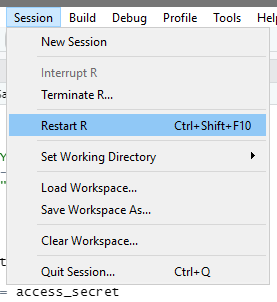

Now, re-run the `create_token()` command with the new API key. This will create a new token containing the correct authentication information and save it in your computer.

Try `search_tweets()` to make sure the new token is working:

```r
search_tweets("#AprilFools")
```

```
## # A tibble: 88 x 90
##    user_id   status_id   created_at          screen_name  text           source
##    <chr>     <chr>       <dttm>              <chr>        <chr>          <chr>
##  1 12387748… 1372366034… 2021-03-18 01:55:34 St3v3nFord   "So what’s th… Twitte…
##  2 79695790… 1372355920… 2021-03-18 01:15:23 mlemleml     "たぶん誰も信じてくれない… Twitte…
##  3 346163240 1372352053… 2021-03-18 01:00:01 AndreiZodian "With luck, M… Twitte…
##  4 11863751… 1372350195… 2021-03-18 00:52:38 lesbianmami… "●：キューボット！後輩ロ… TweetD…
##  5 12529856… 1372346978… 2021-03-18 00:39:51 kravasxxx    "@CEOoflostbo… Twitte…
##  6 13498805… 1372346534… 2021-03-18 00:38:05 Tychris17    "Let's celebr… Twitte…
##  7 532423980 1372343170… 2021-03-18 00:24:43 clubworld77  "@9NewsAUS Is… Twitte…
##  8 15957274… 1372301717… 2021-03-17 21:40:00 MerfRadio    "Perfect!  @t… TweetD…
##  9 22000436  1372292142… 2021-03-17 21:01:57 CurlyAdvent… "Given the fa… Twitte…
## 10 28104907… 1372282518… 2021-03-17 20:23:42 mustlovebre… "@LACMA so ex… Twitte…
## # … with 78 more rows, and 84 more variables: display_text_width <dbl>,
## #   reply_to_status_id <chr>, reply_to_user_id <chr>,
## #   reply_to_screen_name <chr>, is_quote <lgl>, is_retweet <lgl>,
## #   favorite_count <int>, retweet_count <int>, quote_count <int>,
## #   reply_count <int>, hashtags <list>, symbols <list>, urls_url <list>,
## #   urls_t.co <list>, urls_expanded_url <list>, media_url <list>,
## #   media_t.co <list>, media_expanded_url <list>, media_type <list>,
## #   ext_media_url <list>, ext_media_t.co <list>, ext_media_expanded_url <list>,
## #   ext_media_type <chr>, mentions_user_id <list>, mentions_screen_name <list>,
## #   lang <chr>, quoted_status_id <chr>, quoted_text <chr>,
## #   quoted_created_at <dttm>, quoted_source <chr>, quoted_favorite_count <int>,
## #   quoted_retweet_count <int>, quoted_user_id <chr>, quoted_screen_name <chr>,
## #   quoted_name <chr>, quoted_followers_count <int>,
## #   quoted_friends_count <int>, quoted_statuses_count <int>,
## #   quoted_location <chr>, quoted_description <chr>, quoted_verified <lgl>,
## #   retweet_status_id <chr>, retweet_text <chr>, retweet_created_at <dttm>,
## #   retweet_source <chr>, retweet_favorite_count <int>,
## #   retweet_retweet_count <int>, retweet_user_id <chr>,
## #   retweet_screen_name <chr>, retweet_name <chr>,
## #   retweet_followers_count <int>, retweet_friends_count <int>,
## #   retweet_statuses_count <int>, retweet_location <chr>,
## #   retweet_description <chr>, retweet_verified <lgl>, place_url <chr>,
## #   place_name <chr>, place_full_name <chr>, place_type <chr>, country <chr>,
## #   country_code <chr>, geo_coords <list>, coords_coords <list>,
## #   bbox_coords <list>, status_url <chr>, name <chr>, location <chr>,
## #   description <chr>, url <chr>, protected <lgl>, followers_count <int>,
## #   friends_count <int>, listed_count <int>, statuses_count <int>,
## #   favourites_count <int>, account_created_at <dttm>, verified <lgl>,
## #   profile_url <chr>, profile_expanded_url <chr>, account_lang <lgl>,
## #   profile_banner_url <chr>, profile_background_url <chr>,
## #   profile_image_url <chr>
```